# Tarefa2

Lucas Gerlach Nachtigall

16/09/2022

## R Markdown

```r
library(caret)
```

```r
library(ggplot2)
library(gridExtra)
library(GGally)
library(tidyverse)
library(corrplot)
```

## 1 Carregue a base de dados e mostre a estrutura do dataset (str()). O arquivo do dataset não pode ser modificado de forma alguma. A leitura deverá tratar qualquer característica do arquivo.

```r
rm(list=ls())
setwd("~/Ensino-Entreterimento/Graduação UCS/Semestre 8/Computação Aplicada I/Tarefa2-Computação_Aplicada_I")
dadosMain = read.csv2("Dry_Bean_Dataset.csv",header=T)
dados = dadosMain
str(dados)
```

```
## 'data.frame':    13611 obs. of  17 variables:
##  $ Area           : int  28395 28734 29380 30008 30140 30279 30477 30519 30685 30834 ...
##  $ Perimeter      : num  610 638 624 646 620 ...
##  $ MajorAxisLength: num  208 201 213 211 202 ...
##  $ MinorAxisLength: num  174 183 176 183 190 ...
##  $ AspectRation   : num  1.2 1.1 1.21 1.15 1.06 ...
##  $ Eccentricity   : num  0.55 0.412 0.563 0.499 0.334 ...
##  $ ConvexArea     : int  28715 29172 29690 30724 30417 30600 30970 30847 31044 31120 ...
##  $ EquivDiameter  : num  190 191 193 195 196 ...
##  $ Extent         : num  0.764 0.784 0.778 0.783 0.773 ...
##  $ Solidity       : num  0.989 0.985 0.99 0.977 0.991 ...
##  $ roundness      : num  0.958 0.887 0.948 0.904 0.985 ...
##  $ Compactness    : num  0.913 0.954 0.909 0.928 0.971 ...
##  $ ShapeFactor1   : num  0.00733 0.00698 0.00724 0.00702 0.0067 ...
##  $ ShapeFactor2   : num  0.00315 0.00356 0.00305 0.00321 0.00366 ...
##  $ ShapeFactor3   : num  0.834 0.91 0.826 0.862 0.942 ...
##  $ ShapeFactor4   : num  0.999 0.998 0.999 0.994 0.999 ...
##  $ Class          : chr  "SEKER" "SEKER" "SEKER" "SEKER" ...
```

```r
summary(iris)
```

```
##   Sepal.Length    Sepal.Width     Petal.Length    Petal.Width
##  Min.   :4.300   Min.   :2.000   Min.   :1.000   Min.   :0.100
##  1st Qu.:5.100   1st Qu.:2.800   1st Qu.:1.600   1st Qu.:0.300
##  Median :5.800   Median :3.000   Median :4.350   Median :1.300
##  Mean   :5.843   Mean   :3.057   Mean   :3.758   Mean   :1.199
##  3rd Qu.:6.400   3rd Qu.:3.300   3rd Qu.:5.100   3rd Qu.:1.800
##  Max.   :7.900   Max.   :4.400   Max.   :6.900   Max.   :2.500
##        Species
##  setosa    :50
##  versicolor:50
##  virginica :50
##
##
##
```

## 2 Altere a variável do tipo do feijão (Class) para um factor.

```r
dados$Class <- factor(dados$Class)
str(dados$Class)
```

```
##  Factor w/ 7 levels "BARBUNYA","BOMBAY",..: 6 6 6 6 6 6 6 6 6 6 ...
```

## 3 Plote um gráfico de barras que ilustre as quantidades de cada classe.

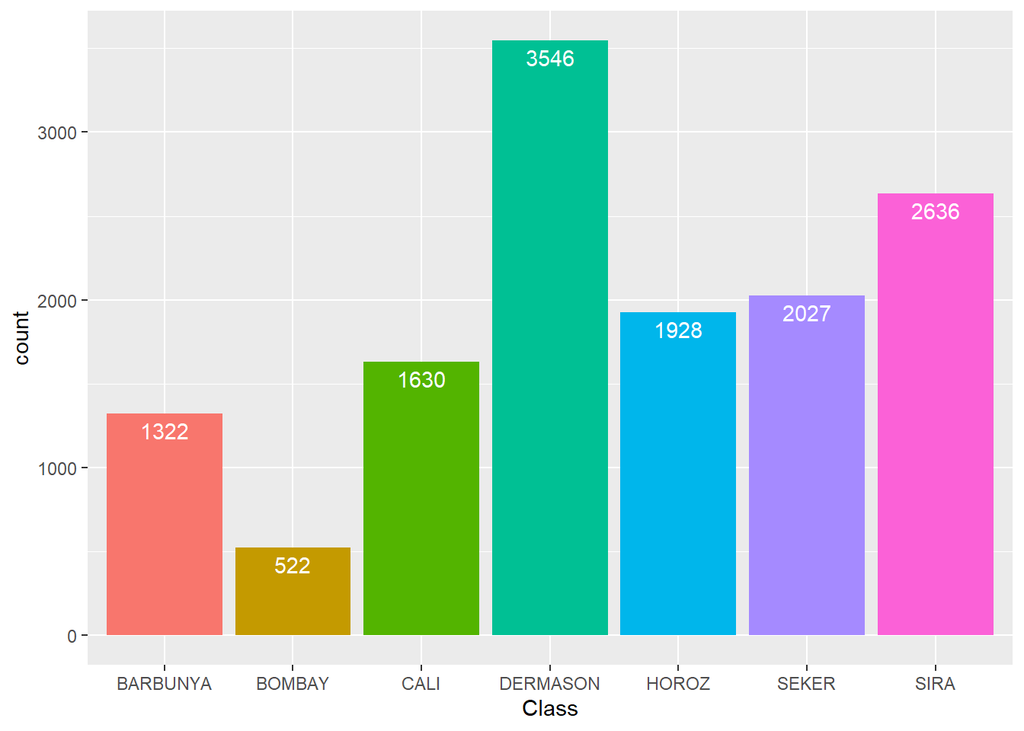

```r
ggplot(dados,aes(Class,fill=Class)) + geom_bar() + geom_text(aes(label = ..count..), stat = "count", vjust = 1.5, colour = "white") + theme(legend.position="none")
```

## 4 Realize a normalização dos dados via Z-score. Plote um boxplot para ilustrar a distribuição de cada variável. Mostre as estatísticas de cada variável (summary).

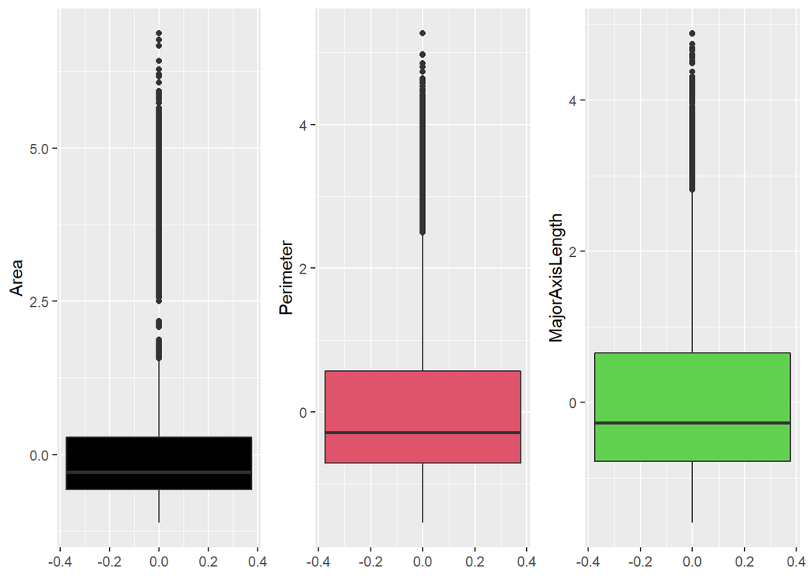

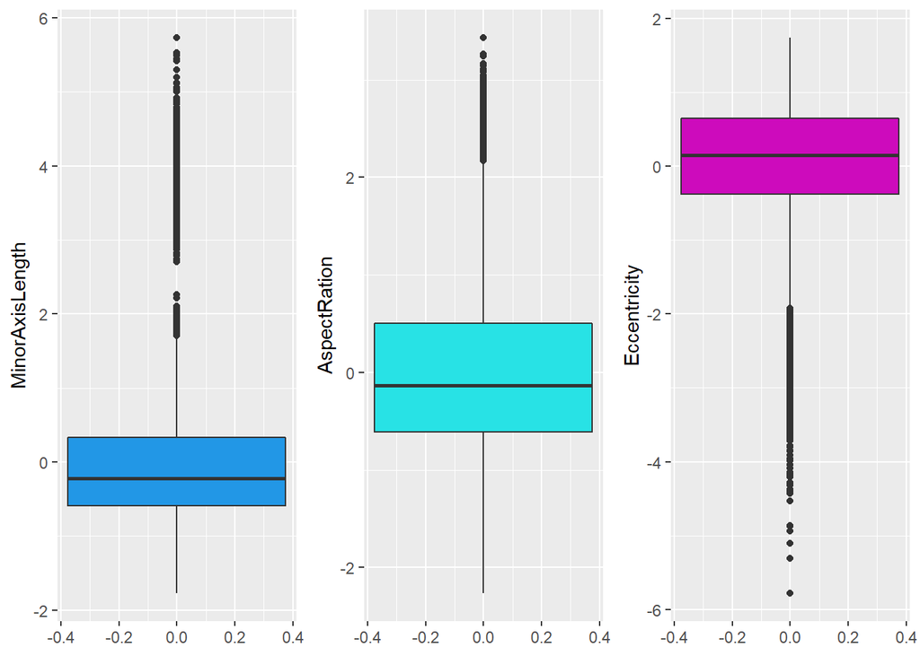

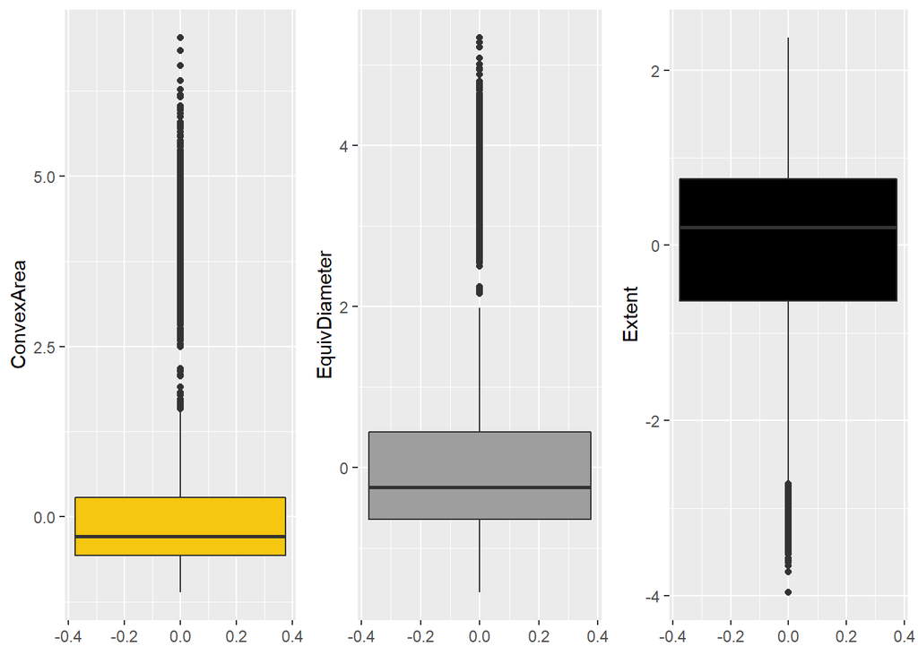

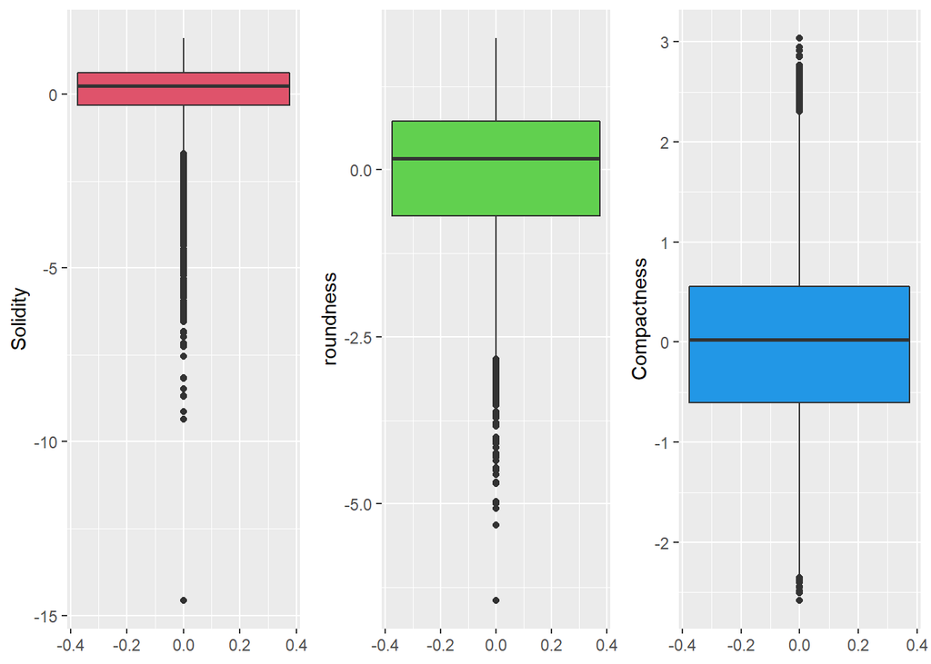

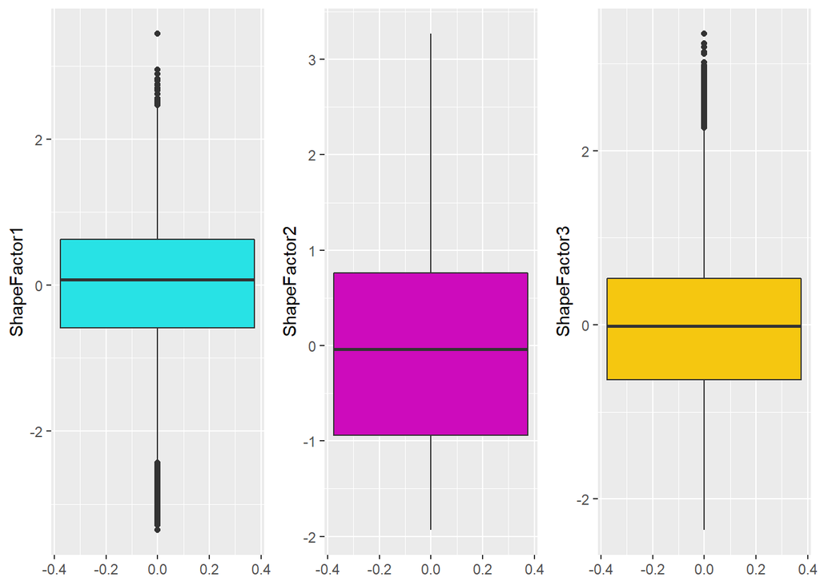

```r
normalizacaoParametros = preProcess(dados,method = c("center","scale"))
dados = predict(normalizacaoParametros, dados)
p = list()
for (i in 1:15) {
  p[[i]] = ggplot(dados, aes_string(y=names(dados)[i])) + geom_boxplot(fill = i) +
    theme(legend.position="none")
  if((i==3) || (i==6) || (i==9) || (i==12) || (i==15)){
    do.call(grid.arrange,c(p[(i-2):i],ncol=3))
  }
}
```

```r
summary(dados)
```

```
##       Area           Perimeter       MajorAxisLength   MinorAxisLength
##  Min.   :-1.1127   Min.   :-1.5425   Min.   :-1.5933   Min.   :-1.7736
##  1st Qu.:-0.5702   1st Qu.:-0.7082   1st Qu.:-0.7800   1st Qu.:-0.5876
##  Median :-0.2863   Median :-0.2816   Median :-0.2714   Median :-0.2188
##  Mean   : 0.0000   Mean   : 0.0000   Mean   : 0.0000   Mean   : 0.0000
##  3rd Qu.: 0.2825   3rd Qu.: 0.5690   3rd Qu.: 0.6576   3rd Qu.: 0.3282
##  Max.   : 6.8738   Max.   : 5.2736   Max.   : 4.8862   Max.   : 5.7355
##
##   AspectRation      Eccentricity       ConvexArea      EquivDiameter
##  Min.   :-2.2636   Min.   :-5.7819   Min.   :-1.1111   Min.   :-1.5516
##  1st Qu.:-0.6119   1st Qu.:-0.3801   1st Qu.:-0.5728   1st Qu.:-0.6421
##  Median :-0.1302   Median : 0.1472   Median :-0.2885   Median :-0.2472
##  Mean   : 0.0000   Mean   : 0.0000   Mean   : 0.0000   Mean   : 0.0000
##  3rd Qu.: 0.5021   3rd Qu.: 0.6475   3rd Qu.: 0.2863   3rd Qu.: 0.4458
##  Max.   : 3.4339   Max.   : 1.7448   Max.   : 7.0359   Max.   : 5.3451
##
##      Extent           Solidity          roundness        Compactness
##  Min.   :-3.9607   Min.   :-14.5689   Min.   :-6.4460   Min.   :-2.5811
##  1st Qu.:-0.6336   1st Qu.: -0.3160   1st Qu.:-0.6920   1st Qu.:-0.6059
##  Median : 0.2063   Median :  0.2446   Median : 0.1659   Median : 0.0229
##  Mean   : 0.0000   Mean   :  0.0000   Mean   : 0.0000   Mean   : 0.0000
##  3rd Qu.: 0.7562   3rd Qu.:  0.6159   3rd Qu.: 0.7323   3rd Qu.: 0.5575
##  Max.   : 2.3726   Max.   :  1.6167   Max.   : 1.9725   Max.   : 3.0373
##
##   ShapeFactor1       ShapeFactor2       ShapeFactor3       ShapeFactor4
##  Min.   :-3.35603   Min.   :-1.93292   Min.   :-2.35617   Min.   :-10.8500
##  1st Qu.:-0.58838   1st Qu.:-0.94387   1st Qu.:-0.62863   1st Qu.: -0.3116
##  Median : 0.07231   Median :-0.03762   Median :-0.01562   Median :  0.3029
##  Mean   : 0.00000   Mean   : 0.00000   Mean   : 0.00000   Mean   :  0.0000
##  3rd Qu.: 0.62749   3rd Qu.: 0.76244   3rd Qu.: 0.52948   3rd Qu.:  0.6457
##  Max.   : 3.44642   Max.   : 3.27086   Max.   : 3.34535   Max.   :  1.0693
##
##       Class
##  BARBUNYA:1322
##  BOMBAY  : 522
##  CALI    :1630
##  DERMASON:3546
##  HOROZ   :1928
##  SEKER   :2027
##  SIRA    :2636
```

## 5 Realize a seleção de características (correlação). Plote o gráfico de correlação. Liste as características que foram removidas.

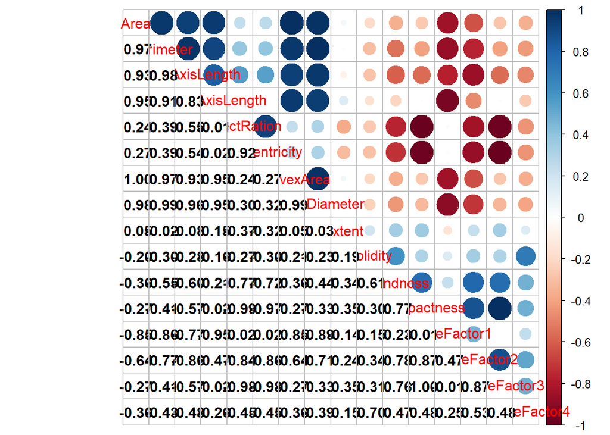

```r
dados = dadosMain
rotulos = dados[,17]
dados = dados[,-17]
matrizCorrelacao = cor(dados)
indicesCorrelacaoForte = findCorrelation(matrizCorrelacao, cutoff=0.95)
corrplot.mixed(matrizCorrelacao,lower.col="black")
```

```r
print(colnames(dados[,indicesCorrelacaoForte]))
```

```
## [1] "MajorAxisLength" "Perimeter"       "EquivDiameter"   "ConvexArea"
## [5] "ShapeFactor3"    "Compactness"     "MinorAxisLength"
```

```r
if (length(indicesCorrelacaoForte) > 0)
    dados[,indicesCorrelacaoForte] = NULL
```

## 6 Plote um gráfico boxplot ou de densidade por variável x classe (organize em 3 colunas). Discuta qual é a variável que teria maior poder de discriminação? Existe alguma classe que pode ser classificada mais facilmente? Justifique a sua escolha.

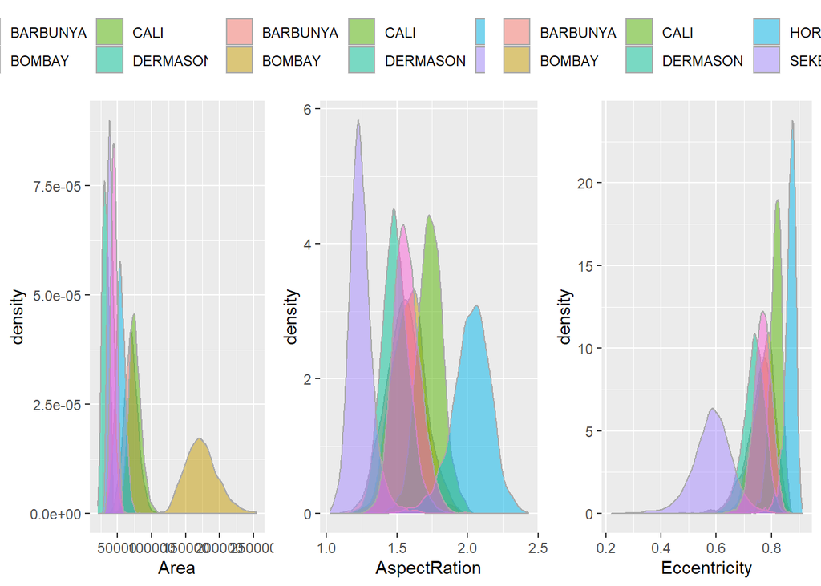

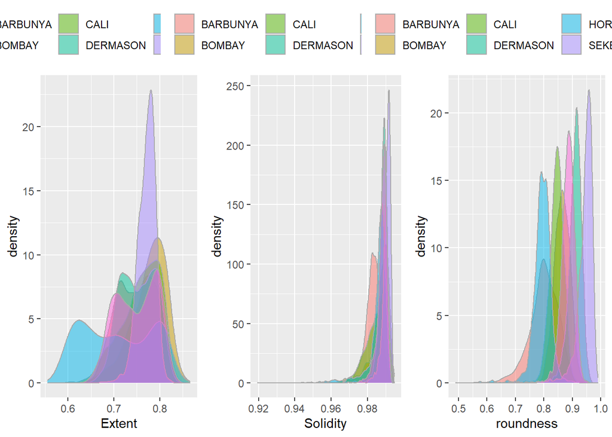

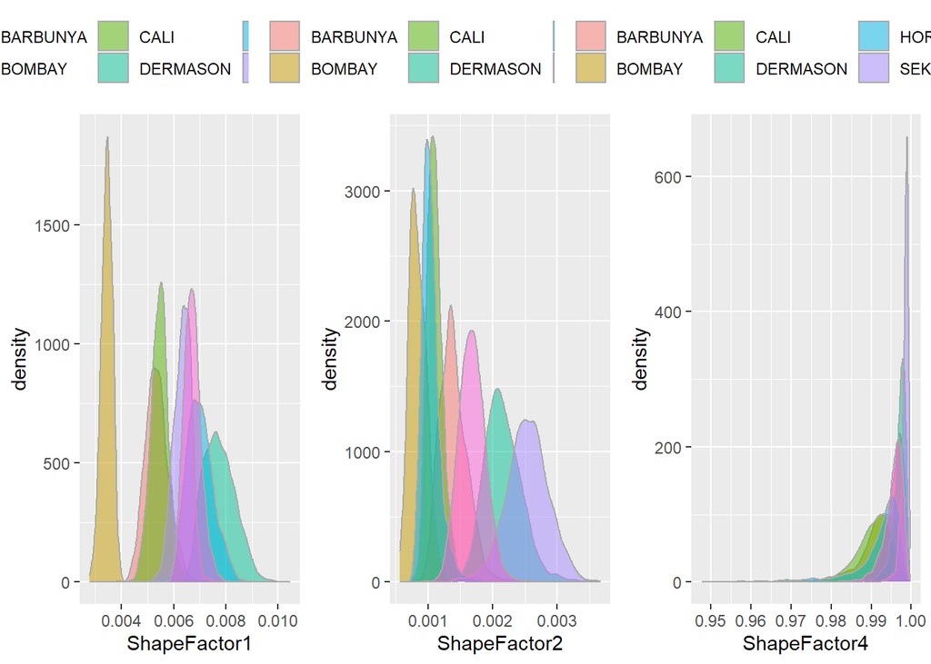

```r
p = list()
dados$Class = dadosMain$Class
for(i in 1:length(dados)){
   p[[i]] = ggplot(dados, aes_string(x=names(dados)[i],fill="Class")) +
            geom_density(alpha=0.5,color="darkgray") +
            theme(legend.position="top", legend.title = element_blank())
   if((i==3) || (i==6) || (i==9) || (i==12) || (i==15)){
    do.call(grid.arrange,c(p[(i-2):i],ncol=3))
  }
}
```

ShapeFactor2 é a variável que teria maior poder de discriminação, pois é a variável que possui maior disperção de densidade entre as classes. Dentre as classes existentes, a Classe “BOMBAY” é a que pode mais facilmente ser classificada pois tanto nas variáveis “Area” e “ShapeFactor1”, esta classe pois grande discrepância das demais classes.

## 7 Realize a projeção do dataset utilizando PCA. Explique as características dos componentes principais estimados. O que se pode explicar sobre os componentes principais utilizando o gráfico biplot. Apresente as características básicas (summary) dos dados.

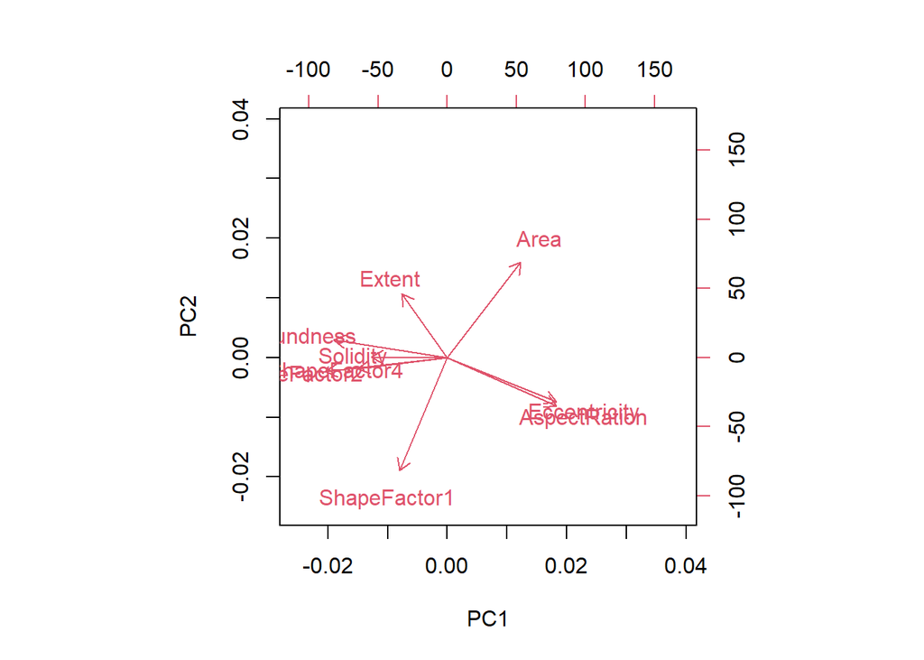

```r
dados = dados[,-length(dados)]
pca = prcomp(dados,center=TRUE,scale=TRUE)
biplot(pca,xlabs = rep("", nrow(dados)))
```

```r
summary(pca)
```

```
## Importance of components:
##                           PC1    PC2    PC3     PC4     PC5     PC6     PC7
## Standard deviation     2.1249 1.3633 1.0695 0.87440 0.65139 0.37872 0.31486
## Proportion of Variance 0.5017 0.2065 0.1271 0.08495 0.04715 0.01594 0.01102
## Cumulative Proportion  0.5017 0.7082 0.8353 0.92022 0.96736 0.98330 0.99431
##                            PC8     PC9
## Standard deviation     0.21469 0.07134
## Proportion of Variance 0.00512 0.00057
## Cumulative Proportion  0.99943 1.00000
```

```r
colnames(dados)
```

```
## [1] "Area"         "AspectRation" "Eccentricity" "Extent"       "Solidity"
## [6] "roundness"    "ShapeFactor1" "ShapeFactor2" "ShapeFactor4"
```

## 8 Analise o dataset projetado com o auxílio do gráfico de boxplot por classe (igual ao do item 6). Compare com o resultado do item 6. Se quiser, pode gerar um gráfico de espalhamento para auxiliar na explicação.

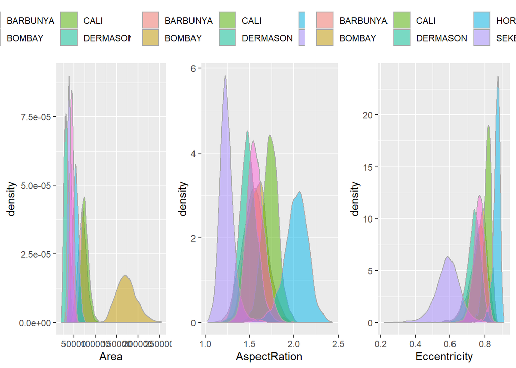

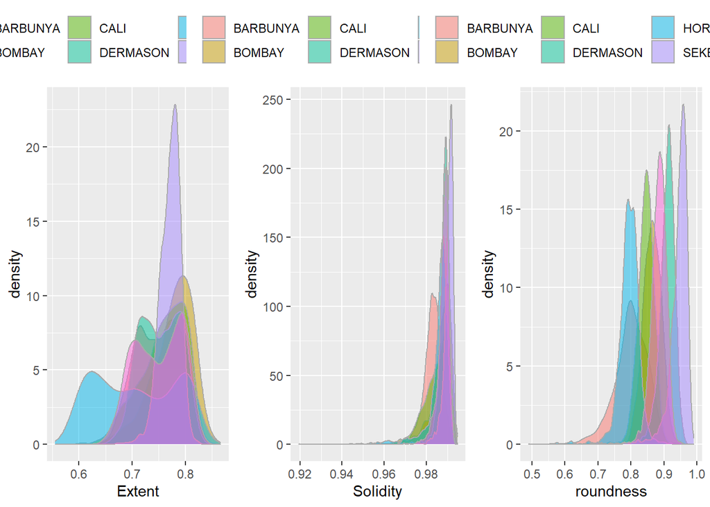

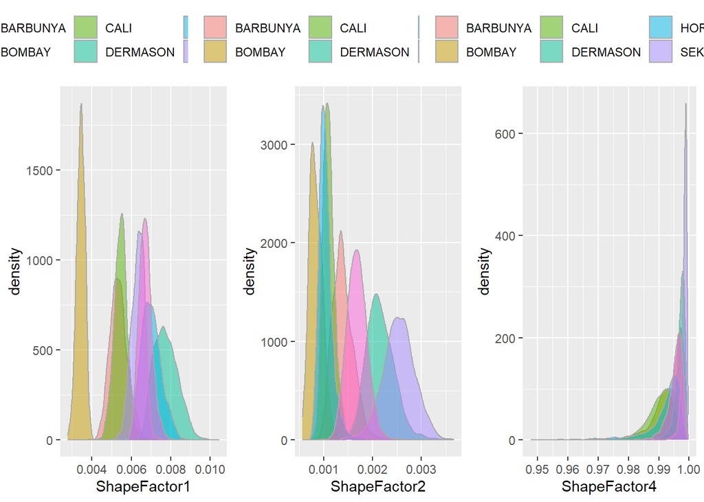

```r
p = list()
dados$Class = dadosMain$Class
for(i in 1:length(dados)){
   p[[i]] = ggplot(dados, aes_string(x=names(dados)[i],fill="Class")) +
            geom_density(alpha=0.5,color="darkgray") +
            theme(legend.position="top", legend.title = element_blank())
   if((i==3) || (i==6) || (i==9) || (i==12) || (i==15)){
    do.call(grid.arrange,c(p[(i-2):i],ncol=3))
  }
}
```

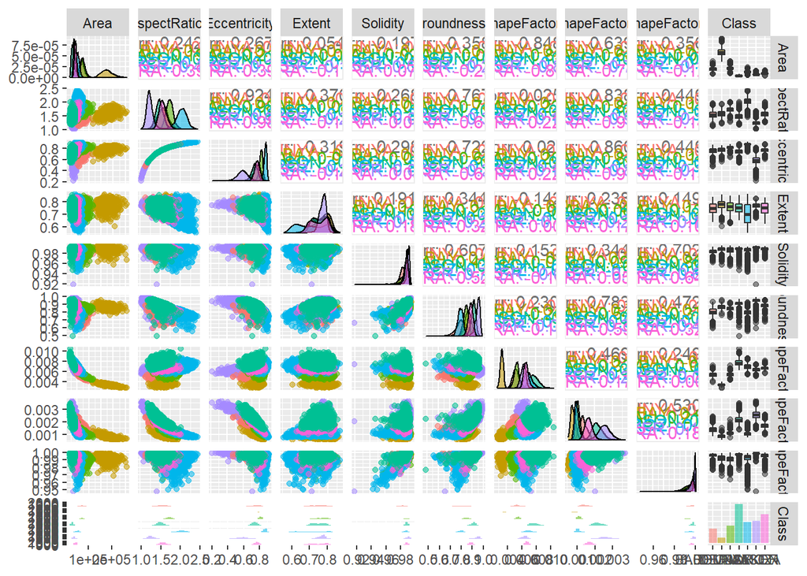

```r
ggpairs(dados,aes(colour=rotulos, alpha=0.1))
```

## 9 É possível reduzir a dimensionalidade dos dados? Explique como!

```r
numeroComponentes = min(which(summary(pca)$importance[3,] > 0.95))
dados = predict(pca,dados)[,1:numeroComponentes]
dados = data.frame(dados)
```

Uma maneira de fazer a redução da dimensionalidade é realizar a Seleção dos autovetores que explicam pelo menos 95% da variância dos dados.

## 10 Analise o dataset reduzido com o auxílio do gráfico de boxplot por classe (igual ao do item 6). Compare com o resultado do item 6 e do item 8. Se quiser, pode gerar um gráfico de espalhamento para auxiliar na explicação.

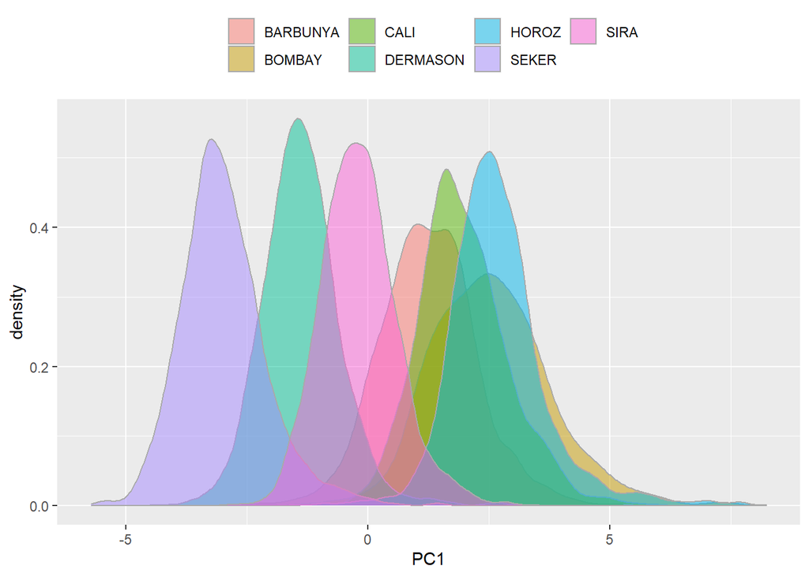

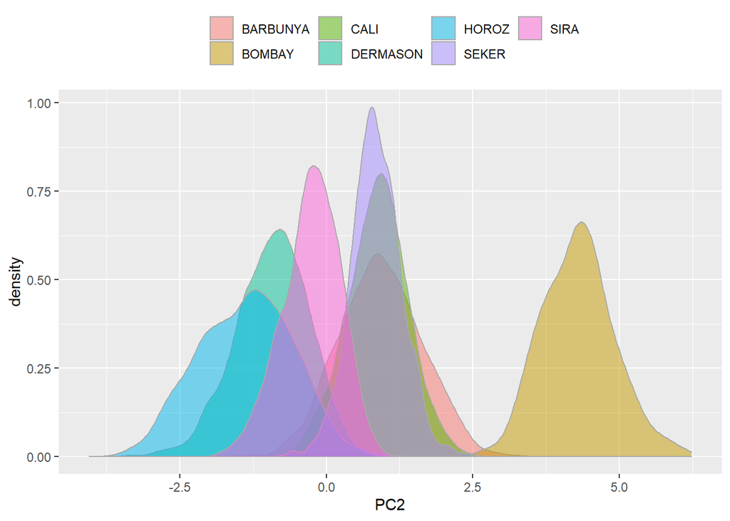

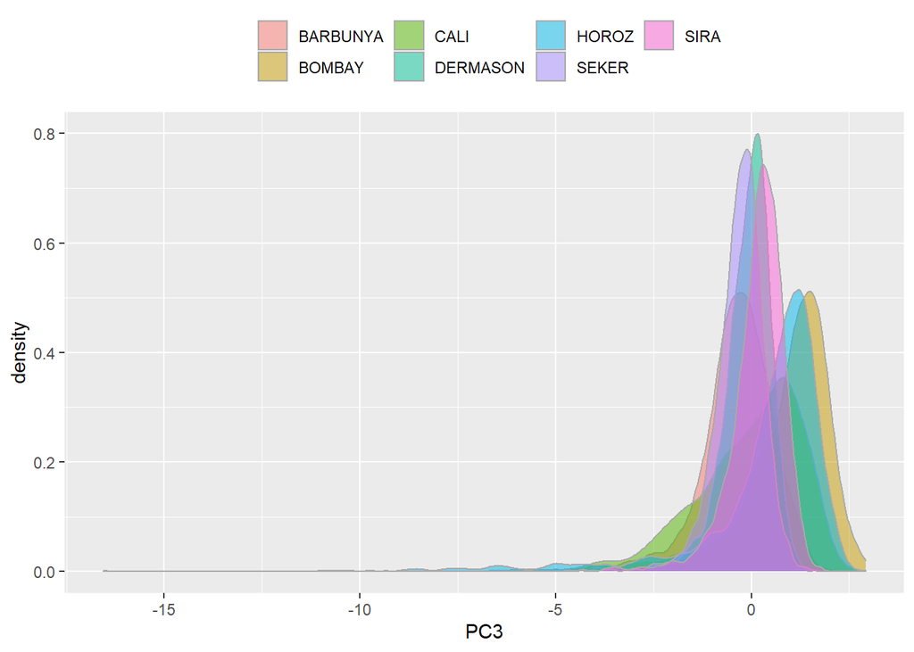

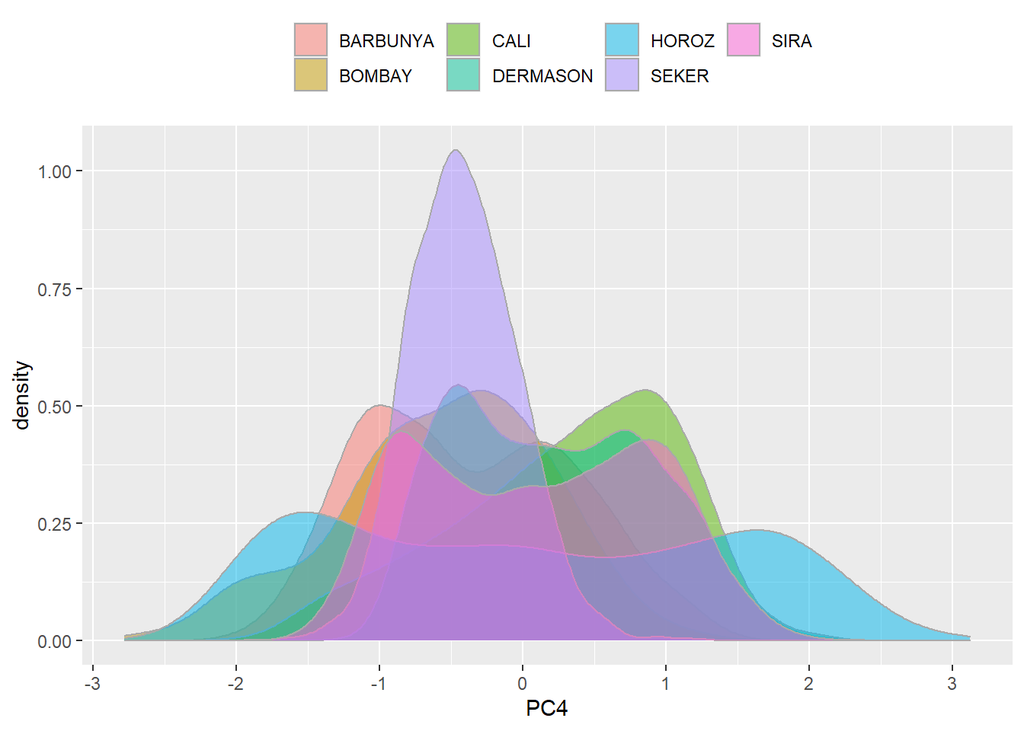

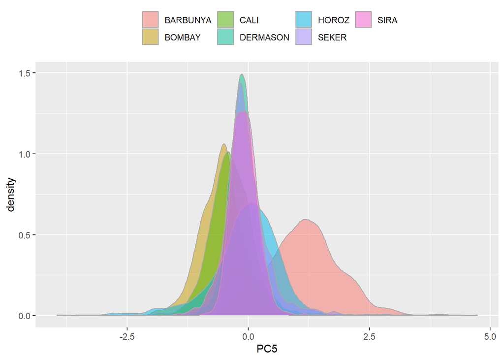

```r
p = list()
dados$Class = dadosMain$Class
for(i in 1:length(dados)){
   p[[i]] = ggplot(dados, aes_string(x=names(dados)[i],fill="Class")) +
            geom_density(alpha=0.5,color="darkgray") +
            theme(legend.position="top", legend.title = element_blank())
   if(i<6){
    do.call(grid.arrange,c(p[i],ncol=1))
  }
}
```

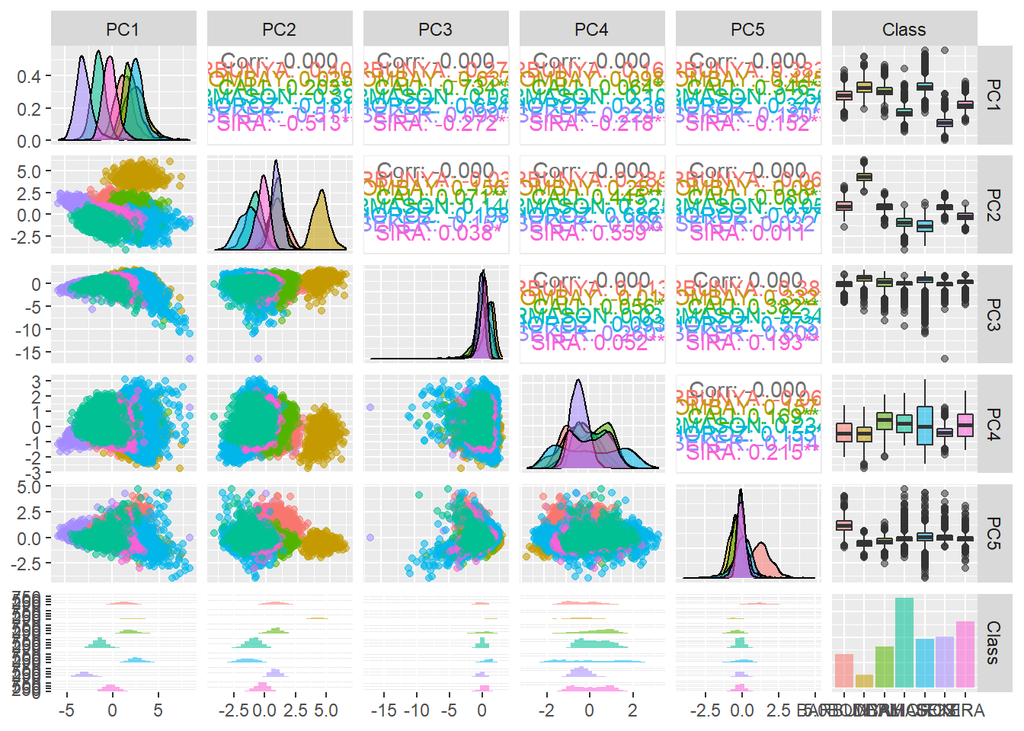

```r
ggpairs(dados,aes(colour=rotulos, alpha=0.1))
```

## 11 Após ter analisado estas informações, quais considerações você faz sobre este conjunto de dados (ou tarefa)?

Com relação à classificação das sementes de feijão, as características de dimensão e forma das variedades de feijão não possuem características discriminatórias externas, o que torna esse processo de classificação complexo. Mas utilizando diversas maneiras de realizar reduções sobre a dimensionalidade dos dados, assim permitindo uma melhor maneira de classificar os dados.